# IODS: Final Assignment

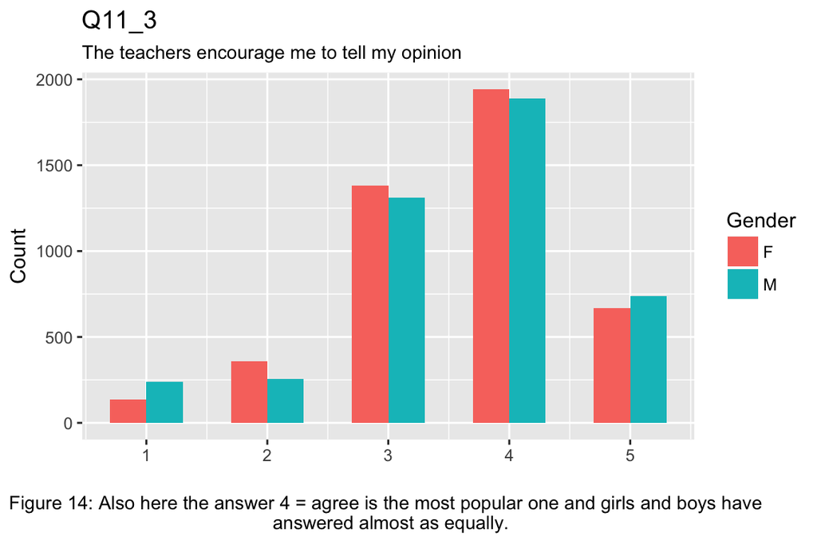

```r
g14 <- ggplot(data = school, aes(x = q11_3, fill = q1))
g14 + geom_bar(width = .6, position = "dodge") + labs(x = "", y = "Count", title ="Q11_3", subtitle = "The teachers encourage me to tell my opinion",  caption = "Figure 14: Also here the answer 4 = agree is the most popular one and girls and boys have \n answered almost as equally.", fill = "Gender") + theme(plot.caption = element_text(hjust = 0.5))
```

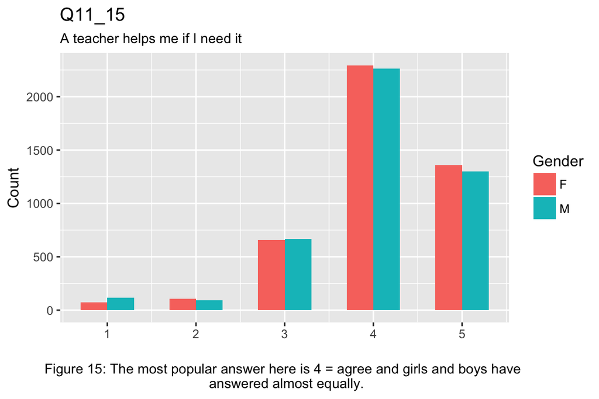

```r
g15 <- ggplot(data = school, aes(x = q11_15, fill = q1))
g15 + geom_bar(width = .6, position = "dodge") + labs(x = "", y = "Count", title ="Q11_15", subtitle = "A teacher helps me if I need it",  caption = "Figure 15: The most popular answer here is 4 = agree and girls and boys have \n answered almost equally.", fill = "Gender") + theme(plot.caption = element_text(hjust = 0.5))
```

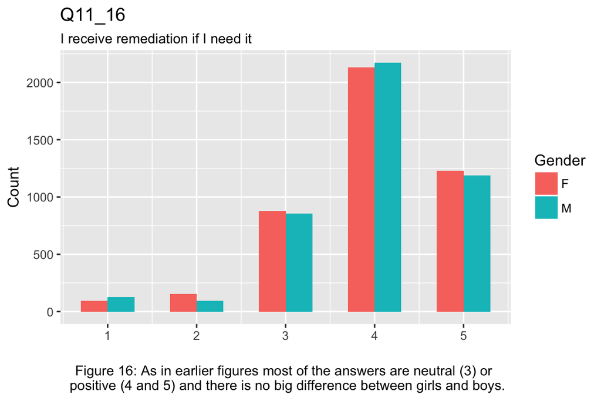

```r
g16 <- ggplot(data = school, aes(x = q11_16, fill = q1))
g16 + geom_bar(width = .6, position = "dodge") + labs(x = "", y = "Count", title ="Q11_16", subtitle = "I receive remediation if I need it",  caption = "Figure 16: As in earlier figures most of the answers are neutral (3) or \n positive (4 and 5) and there is no big difference between girls and boys.", fill = "Gender") + theme(plot.caption = element_text(hjust = 0.5))
```

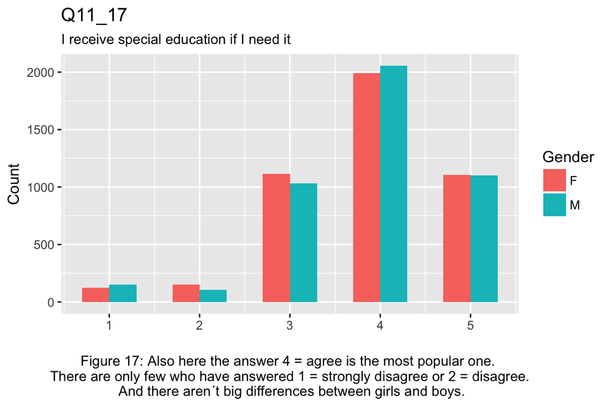

```r
g17 <- ggplot(data = school, aes(x = q11_17, fill = q1))
g17 + geom_bar(width = .6, position = "dodge") + labs(x = "", y = "Count", title ="Q11_17", subtitle = "I receive special education if I need it",  caption = "Figure 17: Also here the answer 4 = agree is the most popular one. \n There are only few who have answered 1 = strongly disagree or 2 = disagree. \n And there aren´t big differences between girls and boys.", fill = "Gender") + theme(plot.caption = element_text(hjust = 0.5))
```

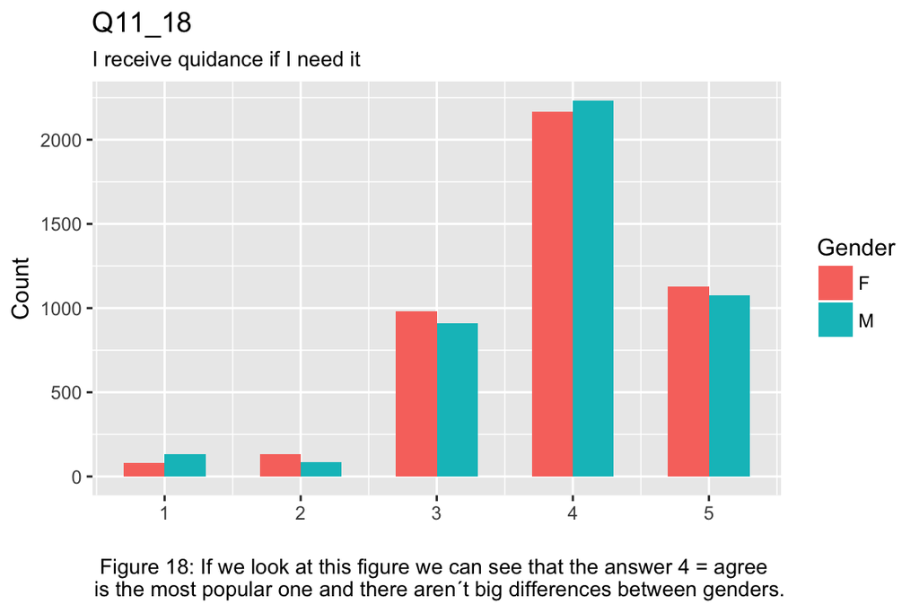

```r
g18 <- ggplot(data = school, aes(x = q11_18, fill = q1))
g18 + geom_bar(width = .6, position = "dodge") + labs(x = "", y = "Count", title ="Q11_18", subtitle = "I receive quidance if I need it",  caption = "Figure 18: If we look at this figure we can see that the answer 4 = agree \n is the most popular one and there aren´t big differences between genders.", fill = "Gender") + theme(plot.caption = element_text(hjust = 0.5))
```

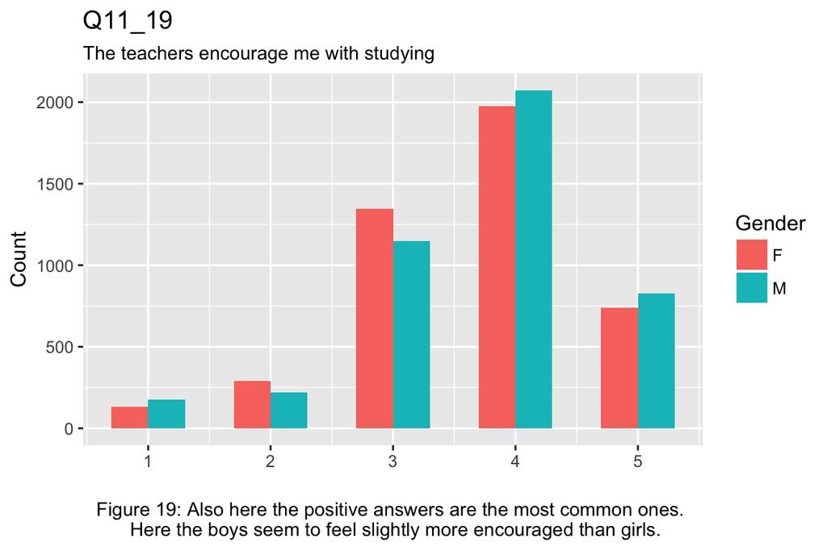

```r
g19 <- ggplot(data = school, aes(x = q11_19, fill = q1))
g19 + geom_bar(width = .6, position = "dodge") + labs(x = "", y = "Count", title ="Q11_19", subtitle = "The teachers encourage me with studying",  caption = "Figure 19: Also here the positive answers are the most common ones. \n Here the boys seem to feel slightly more encouraged than girls.", fill = "Gender") + theme(plot.caption = element_text(hjust = 0.5))
```

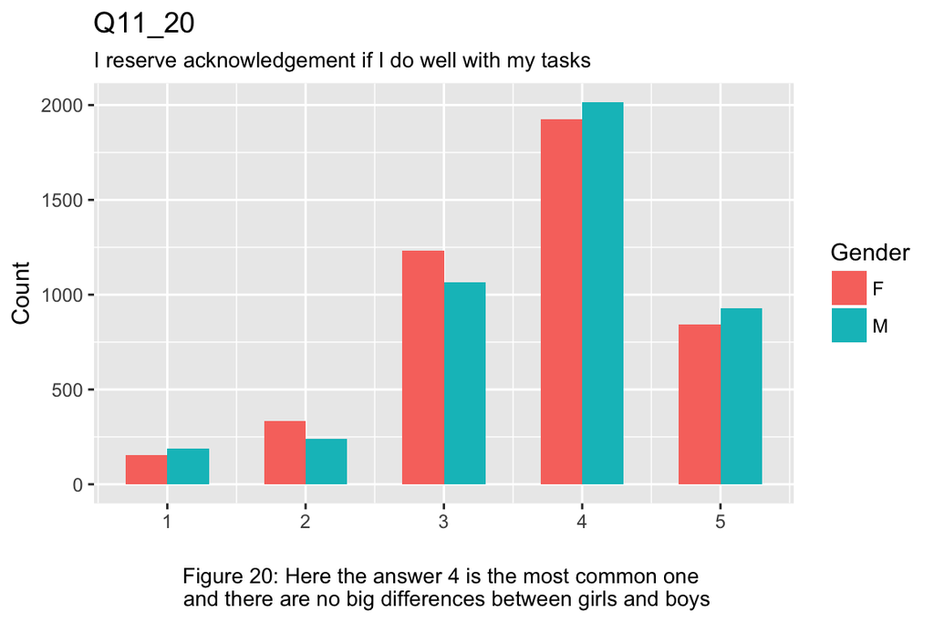

```r
g20 <- ggplot(data = school, aes(x = q11_20, fill = q1))
g20 + geom_bar(width = .6, position = "dodge") + labs(x = "", y = "Count", title ="Q11_20", subtitle = "I reserve acknowledgement if I do well with my tasks",  caption = "Figure 20: Here the answer 4 is the most common one \n and there are no big differences between girls and boys", fill = "Gender") + theme(plot.caption = element_text(hjust = 0.5))
```

As we can see from the plots above most of the pupils feel that they are appreciated and supported by their teachers and parents. But in every question there is a small minority of pupils who don´t agree with these statements.

## Symptoms and illnesses

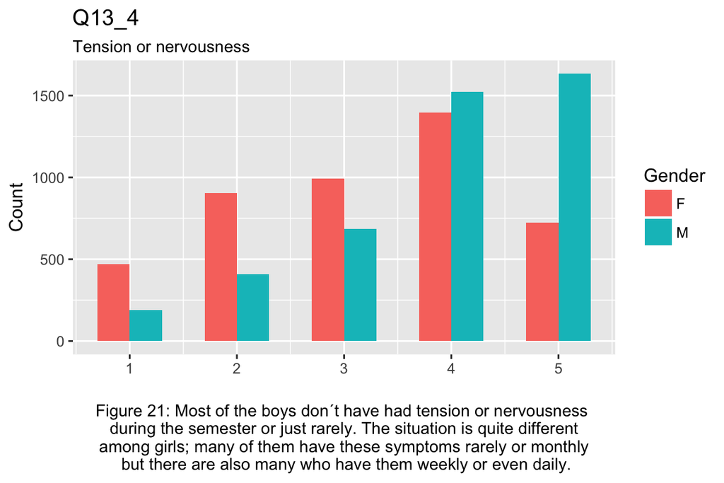

```r
g21 <- ggplot(data = school, aes(x = q13_4, fill = q1))
g21 + geom_bar(width = .6, position = "dodge") + labs(x = "", y = "Count", title ="Q13_4", subtitle = "Tension or nervousness",  caption = "Figure 21: Most of the boys don´t have had tension or nervousness \n during the semester or just rarely. The situation is quite different \n among girls; many of them have these symptoms rarely or monthly \n but there are also many who have them weekly or even daily.", fill = "Gender") + theme(plot.caption = element_text(hjust = 0.5))
```

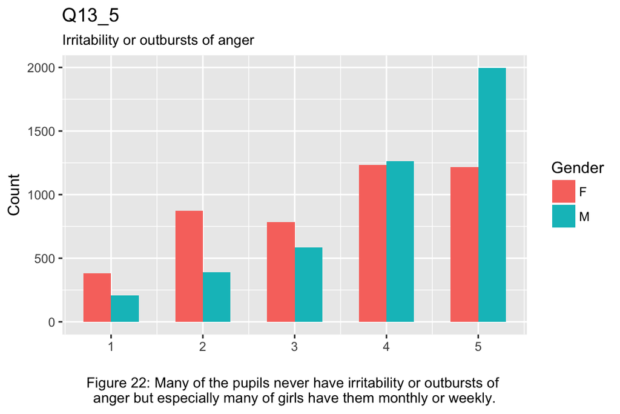

```r
g22 <- ggplot(data = school, aes(x = q13_5, fill = q1))
g22 + geom_bar(width = .6, position = "dodge") + labs(x = "", y = "Count", title ="Q13_5", subtitle = "Irritability or outbursts of anger",  caption = "Figure 22: Many of the pupils never have irritability or outbursts of \n anger but especially many of girls have them monthly or weekly. ", fill = "Gender") + theme(plot.caption = element_text(hjust = 0.5))
```

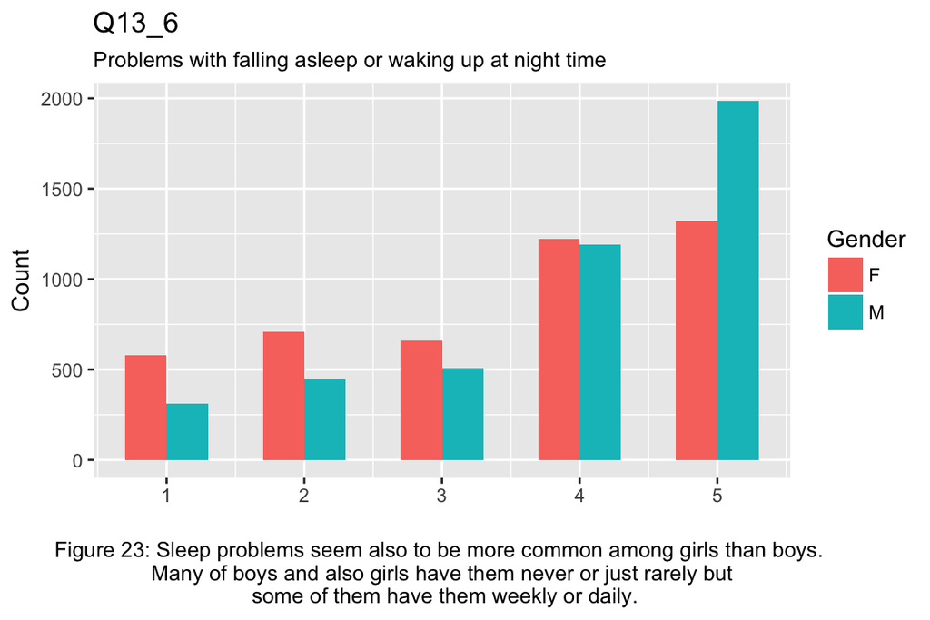

```r
g23 <- ggplot(data = school, aes(x = q13_6, fill = q1))
g23 + geom_bar(width = .6, position = "dodge") + labs(x = "", y = "Count", title ="Q13_6", subtitle = "Problems with falling asleep or waking up at night time",  caption = "Figure 23: Sleep problems seem also to be more common among girls than boys. \n Many of boys and also girls have them never or just rarely but \n some of them have them weekly or daily.", fill = "Gender") + theme(plot.caption = element_text(hjust = 0.5))
```

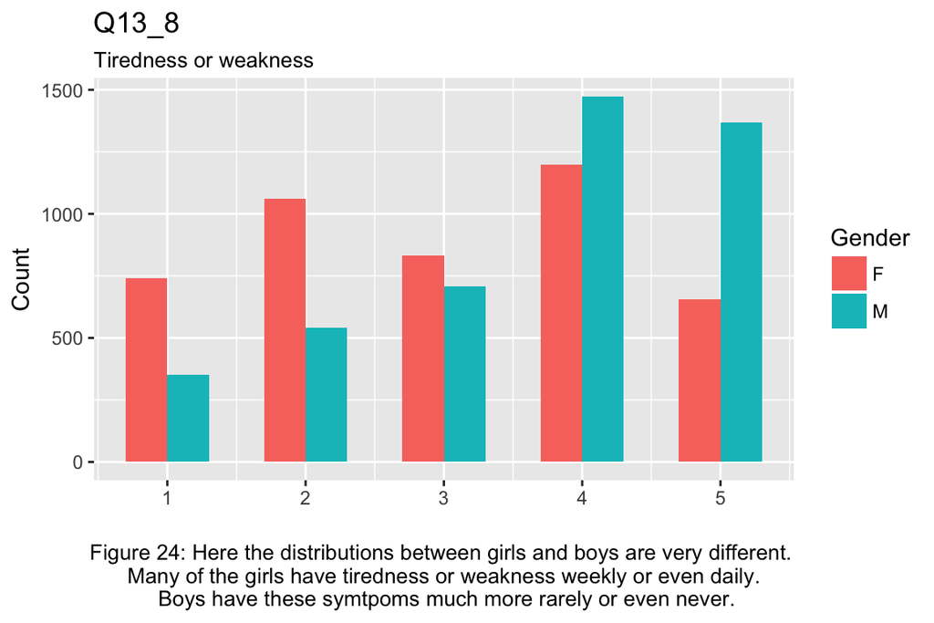

```r
g24 <- ggplot(data = school, aes(x = q13_8, fill = q1))
g24 + geom_bar(width = .6, position = "dodge") + labs(x = "", y = "Count", title ="Q13_8", subtitle = "Tiredness or weakness",  caption = "Figure 24: Here the distributions between girls and boys are very different. \n Many of the girls have tiredness or weakness weekly or even daily. \n Boys have these symtpoms much more rarely or even never.", fill = "Gender") + theme(plot.caption = element_text(hjust = 0.5))
```

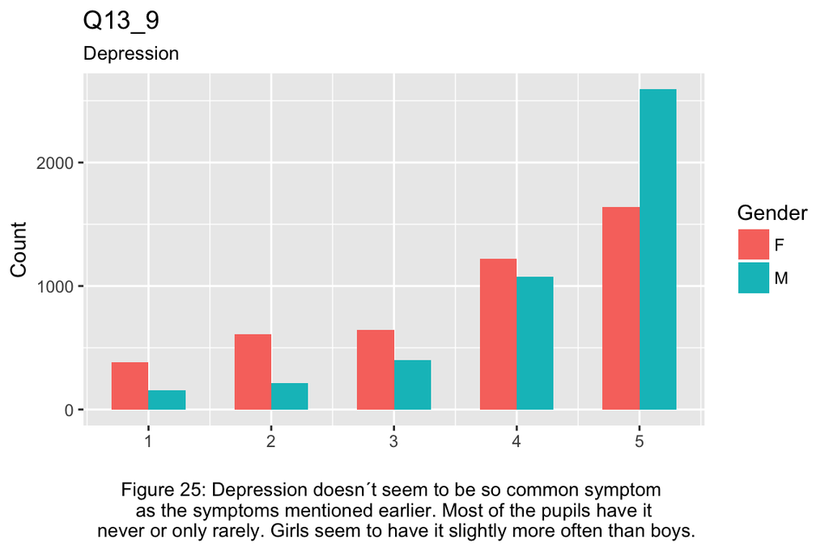

```r
g25 <- ggplot(data = school, aes(x = q13_9, fill = q1))
g25 + geom_bar(width = .6, position = "dodge") + labs(x = "", y = "Count", title ="Q13_9", subtitle = "Depression",  caption = "Figure 25: Depression doesn´t seem to be so common symptom \n as the symptoms mentioned earlier. Most of the pupils have it \n never or only rarely. Girls seem to have it slightly more often than boys.", fill = "Gender") + theme(plot.caption = element_text(hjust = 0.5))
```

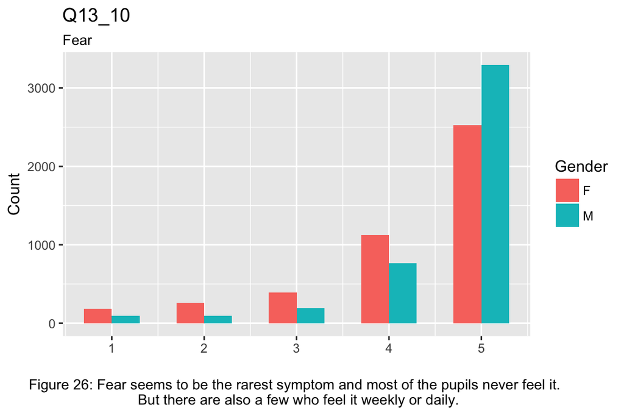

```r
g26 <- ggplot(data = school, aes(x = q13_10, fill = q1))
g26 + geom_bar(width = .6, position = "dodge") + labs(x = "", y = "Count", title ="Q13_10", subtitle = "Fear",  caption = "Figure 26: Fear seems to be the rarest symptom and most of the pupils never feel it. \n But there are also a few who feel it weekly or daily.", fill = "Gender") + theme(plot.caption = element_text(hjust = 0.5))
```

As we can see these variables have more variation between girls and boys. Girls seem to have especially more tiredness, weakness and sleep problems. And many of the boys have rarely or never these symtomps although we can´t say on the grounds of these graphs whether they are always the same persons who have answered for example “never” to these questions.

Now that we have explored the distributions of the chosen variables it´s time for logistic regression.

# Logistic regression

I will use here the binomial variables of symptoms and illnesses instead of the original ones. I will also use bidirectional elimination of the variables to find the best model.

## Tension or nervousness

```r
m1 <- glm(q13_4often ~ q1 + q6_7 + q6_8 + q7_9 + q7_10 + q7_11 + q7_12 + q10_1 + q10_2 + q10_3 + q10_4 + q10_5 + q11_1 + q11_2 + q11_3 + q11_15 + q11_16 + q11_17 + q11_18 + q11_19 + q11_20, data = school, family = "binomial")
sm1 <- step(m1, direction="both")
```

```
## Start:  AIC=8474.88
## q13_4often ~ q1 + q6_7 + q6_8 + q7_9 + q7_10 + q7_11 + q7_12 +
##     q10_1 + q10_2 + q10_3 + q10_4 + q10_5 + q11_1 + q11_2 + q11_3 +
##     q11_15 + q11_16 + q11_17 + q11_18 + q11_19 + q11_20
##
##          Df Deviance    AIC
## - q11_19  1   8431.0 8473.0
## - q10_4   1   8431.0 8473.0
## - q7_10   1   8431.1 8473.1
## - q6_7    1   8431.1 8473.1
## - q11_18  1   8431.2 8473.2
## - q11_16  1   8431.5 8473.5
## - q6_8    1   8432.2 8474.2
## <none>        8430.9 8474.9
## - q11_15  1   8433.1 8475.1
## - q10_2   1   8433.8 8475.8
## - q11_17  1   8433.9 8475.9
## - q10_5   1   8434.5 8476.5
## - q7_12   1   8434.6 8476.6
## - q7_11   1   8435.3 8477.3
## - q11_20  1   8435.7 8477.7
## - q11_3   1   8435.9 8477.9
## - q7_9    1   8440.5 8482.5
## - q10_1   1   8442.6 8484.6
## - q11_1   1   8443.0 8485.0
## - q10_3   1   8451.7 8493.7
## - q11_2   1   8475.6 8517.6
## - q1      1   8821.8 8863.8
##
## Step:  AIC=8473
## q13_4often ~ q1 + q6_7 + q6_8 + q7_9 + q7_10 + q7_11 + q7_12 +
##     q10_1 + q10_2 + q10_3 + q10_4 + q10_5 + q11_1 + q11_2 + q11_3 +
##     q11_15 + q11_16 + q11_17 + q11_18 + q11_20
##
##          Df Deviance    AIC
## - q10_4   1   8431.1 8471.1
## - q7_10   1   8431.2 8471.2
## - q6_7    1   8431.3 8471.3
## - q11_18  1   8431.3 8471.3
## - q11_16  1   8431.6 8471.6
```

[output cut: 203 more lines]

```
## + q11_19  1   8435.2 8465.2
## + q11_18  1   8435.3 8465.3
## + q10_4   1   8435.3 8465.3
## + q6_7    1   8435.4 8465.4
## - q10_5   1   8439.4 8465.4
## - q11_3   1   8439.8 8465.8
## - q7_11   1   8440.5 8466.5
## - q11_17  1   8440.7 8466.7
## - q11_20  1   8442.0 8468.0
## - q10_1   1   8447.8 8473.8
## - q11_1   1   8449.1 8475.1
## - q7_9    1   8452.6 8478.6
## - q10_3   1   8462.0 8488.0
## - q11_2   1   8480.1 8506.1
## - q1      1   8830.9 8856.9
```

```r
summary.glm(sm1)
```

```
##
## Call:
## glm(formula = q13_4often ~ q1 + q7_9 + q7_11 + q7_12 + q10_1 +
##     q10_2 + q10_3 + q10_5 + q11_1 + q11_2 + q11_3 + q11_17 +
##     q11_20, family = "binomial", data = school)
##
## Deviance Residuals:
##     Min       1Q   Median       3Q      Max
## -1.9389  -0.7259  -0.5097  -0.3172   2.5388
##
## Coefficients:
##             Estimate Std. Error z value Pr(>|z|)
## (Intercept)  2.46767    0.17198  14.349  < 2e-16 ***
## q1M         -1.10984    0.05792 -19.163  < 2e-16 ***
## q7_9        -0.14314    0.03435  -4.167 3.08e-05 ***
## q7_11       -0.07827    0.03449  -2.269 0.023250 *
## q7_12        0.06862    0.04086   1.679 0.093087 .
## q10_1       -0.16781    0.04742  -3.539 0.000402 ***
## q10_2        0.09513    0.05067   1.877 0.060458 .
## q10_3       -0.20166    0.03880  -5.198 2.02e-07 ***
## q10_5        0.07104    0.03557   1.997 0.045803 *
## q11_1       -0.17837    0.04804  -3.713 0.000205 ***
## q11_2       -0.26772    0.03997  -6.698 2.11e-11 ***
## q11_3        0.08537    0.04069   2.098 0.035895 *
## q11_17      -0.08167    0.03541  -2.307 0.021072 *
## q11_20      -0.09245    0.03576  -2.586 0.009721 **
## ---
## Signif. codes:  0 '***' 0.001 '**' 0.01 '*' 0.05 '.' 0.1 ' ' 1
##
## (Dispersion parameter for binomial family taken to be 1)
##
##     Null deviance: 9435.8  on 8927  degrees of freedom
## Residual deviance: 8435.4  on 8914  degrees of freedom
## AIC: 8463.4
##
## Number of Fisher Scoring iterations: 4
```

Here are the coefficients of the model:

```r
coef(sm1)
```

```
## (Intercept)         q1M        q7_9       q7_11       q7_12       q10_1
##  2.46766805 -1.10984129 -0.14313914 -0.07826532  0.06861627 -0.16780850
##       q10_2       q10_3       q10_5       q11_1       q11_2       q11_3
##  0.09513441 -0.20166275  0.07104310 -0.17837455 -0.26772017  0.08537007
##      q11_17      q11_20
## -0.08167114 -0.09244819
```

### Odds ratios and confidence intervals of the model:

```r
OR1 <- coef(sm1) %>% exp
CI1 <- confint(sm1) %>% exp
cbind(OR1, CI1)
```

```
##                    OR1     2.5 %     97.5 %
## (Intercept) 11.7949096 8.4312210 16.5478211
## q1M          0.3296113 0.2940685  0.3690331
## q7_9         0.8666335 0.8102972  0.9271060
## q7_11        0.9247190 0.8643329  0.9894760
## q7_12        1.0710251 0.9887565  1.1605400
## q10_1        0.8455157 0.7705556  0.9280226
## q10_2        1.0998067 0.9960525  1.2149880
## q10_3        0.8173705 0.7576390  0.8821260
## q10_5        1.0736275 1.0016896  1.1516057
## q11_1        0.8366290 0.7614735  0.9192866
## q11_2        0.7651219 0.7074488  0.8274660
## q11_3        1.0891200 1.0058402  1.1798036
## q11_17       0.9215750 0.8598670  0.9879121
## q11_20       0.9116964 0.8500766  0.9780008
```

If we look at the odds ratios and their confidence intervals we can see that 9 of the 13 variables in the model have odds ratios and their confidence intervals under 1. Gender has the biggest impact in this model (OR = 0.330) so odds to tension and nervousness are smaller among boys than girls. Other odds ratios have their upper limits of confidence intervals near 1 or even over it so they have quite small impact. After gender q11_2 = “At school I´m regarded as a person who has a meaning.” (OR = 0.765) and q10_3 “My parents help me with my homework if necessary.” (OR = 0.817) have the smallest odds ratios meaning that the bigger the score the smaller the odds to have tension and nervousness daily or weekly.

### The predictive power of this model

```r
probabilities1 <- predict(sm1, type = "response")
school <- mutate(school, probability1 = probabilities1)
school <- mutate(school, prediction1 = probability1 > 0.5)
table(q13_4often = school$q13_4often, prediction = school$prediction1)
```

```
##           prediction
## q13_4often FALSE TRUE
##      FALSE  6787  166
##      TRUE   1725  250
```

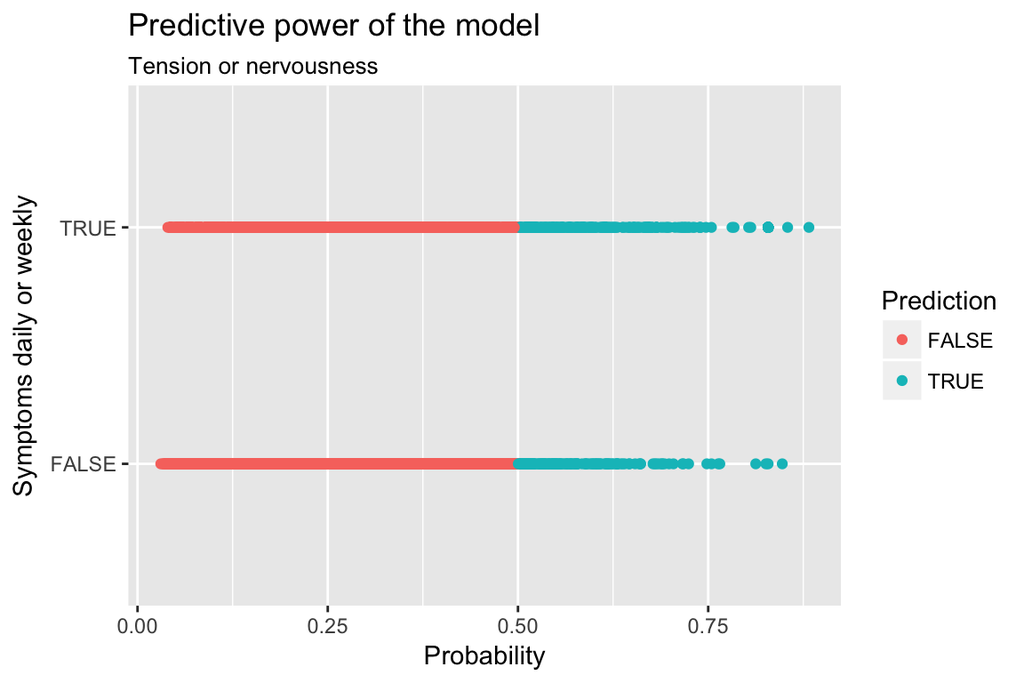

```r
gpp1 <- ggplot(school, aes(x = probability1, y = q13_4often, col = prediction1))
gpp1b <- gpp1 + geom_point() + labs(x = "Probability", y = "Symptoms daily or weekly", title ="Predictive power of the model", subtitle = "Tension or nervousness", color = "Prediction")
gpp1b
```

```r
table(q13_4often = school$q13_4often, prediction = school$prediction1) %>% prop.table() %>% addmargins()
```

```
##           prediction
## q13_4often      FALSE       TRUE        Sum
##      FALSE 0.76019265 0.01859319 0.77878584
##      TRUE  0.19321237 0.02800179 0.22121416
##      Sum   0.95340502 0.04659498 1.00000000
```

```r
loss_func1 <- function(class, prob) {
  n_wrong <- abs(class - prob) > 0.5
  mean(n_wrong)
}
loss_func1(class = school$q13_4often, prob = school$probability1)
```

```
## [1] 0.2118056
```

```r
cv1 <- cv.glm(data = school, cost = loss_func1, glmfit = sm1, K = 10)
cv1$delta[1]
```

```
## [1] 0.2112455
```

As we can see from the matrix above there is approximately 76% chance to get true negative and approximately 3% chance to get true positive with this model so the predictive power of it is very low if we try to find pupils who have tension or nervousness daily or weekly. The average number of wrong predictions is approximately 0.21.

## Irritability or outbursts of anger

```r
m2 <- glm(q13_5often ~ q1 + q6_7 + q6_8 + q7_9 + q7_10 + q7_11 + q7_12 + q10_1 + q10_2 + q10_3 + q10_4 + q10_5 + q11_1 + q11_2 + q11_3 + q11_15 + q11_16 + q11_17 + q11_18 + q11_19 + q11_20, data = school, family = "binomial")
sm2 <- step(m2, direction="both")
```

```
## Start:  AIC=8156.81
## q13_5often ~ q1 + q6_7 + q6_8 + q7_9 + q7_10 + q7_11 + q7_12 +
##     q10_1 + q10_2 + q10_3 + q10_4 + q10_5 + q11_1 + q11_2 + q11_3 +
##     q11_15 + q11_16 + q11_17 + q11_18 + q11_19 + q11_20
##
##          Df Deviance    AIC
## - q11_19  1   8112.8 8154.8
## - q10_5   1   8112.9 8154.9
## - q11_20  1   8112.9 8154.9
## - q6_8    1   8112.9 8154.9
## - q11_16  1   8112.9 8154.9
## - q11_3   1   8113.0 8155.0
## - q11_18  1   8113.0 8155.0
## - q11_17  1   8113.1 8155.1
## - q10_4   1   8113.2 8155.2
## - q10_2   1   8113.3 8155.3
## - q7_11   1   8113.7 8155.7
## <none>        8112.8 8156.8
## - q11_1   1   8115.7 8157.7
## - q7_12   1   8115.9 8157.9
## - q11_15  1   8116.7 8158.7
## - q7_9    1   8117.4 8159.4
## - q10_1   1   8121.4 8163.4
## - q10_3   1   8121.8 8163.8
## - q6_7    1   8122.1 8164.1
## - q7_10   1   8129.6 8171.6
## - q11_2   1   8137.0 8179.0
## - q1      1   8443.6 8485.6
##
## Step:  AIC=8154.82
## q13_5often ~ q1 + q6_7 + q6_8 + q7_9 + q7_10 + q7_11 + q7_12 +
##     q10_1 + q10_2 + q10_3 + q10_4 + q10_5 + q11_1 + q11_2 + q11_3 +
##     q11_15 + q11_16 + q11_17 + q11_18 + q11_20
##
##          Df Deviance    AIC
## - q10_5   1   8112.9 8152.9
## - q11_20  1   8112.9 8152.9
## - q6_8    1   8112.9 8152.9
## - q11_16  1   8112.9 8152.9
## - q11_3   1   8113.0 8153.0
```

[output cut: 259 more lines]

```
## + q10_4   1   8115.0 8141.0
## + q11_16  1   8115.0 8141.0
## + q11_3   1   8115.0 8141.0
## + q6_8    1   8115.1 8141.1
## + q11_20  1   8115.1 8141.1
## + q10_5   1   8115.1 8141.1
## + q11_19  1   8115.2 8141.2
## - q7_9    1   8120.0 8142.0
## - q11_15  1   8120.5 8142.5
## - q10_1   1   8125.9 8147.9
## - q6_7    1   8126.3 8148.3
## - q10_3   1   8131.3 8153.3
## - q7_10   1   8133.6 8155.6
## - q11_2   1   8141.1 8163.1
## - q1      1   8452.9 8474.9
```

```r
summary.glm(sm2)
```

```
##
## Call:
## glm(formula = q13_5often ~ q1 + q6_7 + q7_9 + q7_10 + q7_12 +
##     q10_1 + q10_3 + q11_1 + q11_2 + q11_15 + q11_17, family = "binomial",
##     data = school)
##
## Deviance Residuals:
##     Min       1Q   Median       3Q      Max
## -2.0683  -0.6979  -0.5013  -0.3182   2.5982
##
## Coefficients:
##             Estimate Std. Error z value Pr(>|z|)
## (Intercept)  3.07026    0.17340  17.706  < 2e-16 ***
## q1M         -1.05655    0.05954 -17.745  < 2e-16 ***
## q6_7        -0.11104    0.03312  -3.352 0.000802 ***
## q7_9        -0.08734    0.03941  -2.216 0.026677 *
## q7_10       -0.20042    0.04667  -4.294 1.75e-05 ***
## q7_12        0.07116    0.04355   1.634 0.102274
## q10_1       -0.13499    0.04099  -3.294 0.000989 ***
## q10_3       -0.14595    0.03611  -4.042 5.29e-05 ***
## q11_1       -0.07891    0.04790  -1.648 0.099447 .
## q11_2       -0.20214    0.03953  -5.114 3.15e-07 ***
## q11_15      -0.10855    0.04689  -2.315 0.020627 *
## q11_17      -0.05843    0.04014  -1.456 0.145482
## ---
## Signif. codes:  0 '***' 0.001 '**' 0.01 '*' 0.05 '.' 0.1 ' ' 1
##
## (Dispersion parameter for binomial family taken to be 1)
##
##     Null deviance: 9108.2  on 8927  degrees of freedom
## Residual deviance: 8115.2  on 8916  degrees of freedom
## AIC: 8139.2
##
## Number of Fisher Scoring iterations: 4
```

The variables which have the greatest and most significant negative connection to irritability or outbursts of anger are

- q1m = Gender: Male
- q6_7 = The rules of the school are reasonable.
- q7_10 = It is easy to get along with the teachers.
- q10_1 = My parents appreciate my schoolwork.
- q10_3 = My parents help me with my homework if necessary.
- q11_2 = At school I´m regarded as a person who has a meaning.

Here are the coefficients of the model:

```r
coef(sm2)
```

```
## (Intercept)         q1M        q6_7        q7_9       q7_10       q7_12
##  3.07026075 -1.05654751 -0.11103838 -0.08733602 -0.20042246  0.07115859
##       q10_1       q10_3       q11_1       q11_2      q11_15      q11_17
## -0.13498886 -0.14595405 -0.07890931 -0.20213738 -0.10854675 -0.05842705
```

### Odds ratios and confidence intervals of the model:

```r
OR2 <- coef(sm2) %>% exp
CI2 <- confint(sm2) %>% exp
cbind(OR2, CI2)
```

```
##                    OR2      2.5 %     97.5 %
## (Intercept) 21.5475204 15.3674489 30.3301034
## q1M          0.3476540  0.3091703  0.3904689
## q6_7         0.8949044  0.8387684  0.9550901
## q7_9         0.9163691  0.8484215  0.9901792
## q7_10        0.8183849  0.7467967  0.8967632
## q7_12        1.0737515  0.9860996  1.1697056
## q10_1        0.8737256  0.8063424  0.9469165
## q10_3        0.8641974  0.8053142  0.9277871
## q11_1        0.9241237  0.8414159  1.0152317
## q11_2        0.8169827  0.7561408  0.8828928
## q11_15       0.8971370  0.8183430  0.9835291
## q11_17       0.9432470  0.8721218  1.0207607
```

If we look at the odds ratios here we can see that also here the most of the variables have their odds ratios near to one or their intervals even both sides of it. Smallest odds ratio is on gender (OR = 0.348) meaning that boys have smaller odds to have irritability or outbursts of anger daily or weekly. After gender the smallest odds ratios are on q11_2 “At school I´m regarded as a person who has a meaning.” (OR = 0.817), q7_10 “It is easy to get along with the teachers.” (OR = 0.818) and q10_3 (OR = 0.864) “My parents help me with my homework if necessary.”

### The predictive power of this model

```r
probabilities2 <- predict(sm2, type = "response")
school <- mutate(school, probability2 = probabilities2)
school <- mutate(school, prediction2 = probability2 > 0.5)
table(q13_5often = school$q13_5often, prediction = school$prediction2)
```

```
##           prediction
## q13_5often FALSE TRUE
##      FALSE  6937  142
##      TRUE   1621  228
```

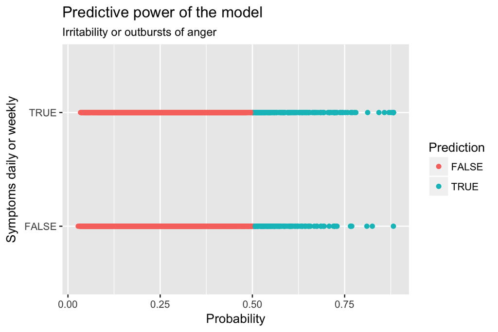

```r
gpp2 <- ggplot(school, aes(x = probability2, y = q13_5often, col = prediction2))
gpp2b <- gpp2 + geom_point() + labs(x = "Probability", y = "Symptoms daily or weekly", title ="Predictive power of the model", subtitle = "Irritability or outbursts of anger", color = "Prediction")
gpp2b
```

```r
table(q13_5often = school$q13_5often, prediction = school$prediction2) %>% prop.table() %>% addmargins()
```

```
##           prediction
## q13_5often      FALSE       TRUE        Sum
##      FALSE 0.77699373 0.01590502 0.79289875
##      TRUE  0.18156362 0.02553763 0.20710125
##      Sum   0.95855735 0.04144265 1.00000000
```

```r
loss_func2 <- function(class, prob) {
  n_wrong <- abs(class - prob) > 0.5
  mean(n_wrong)
}
loss_func2(class = school$q13_5often, prob = school$probability2)
```

```
## [1] 0.1974686
```

```r
cv2 <- cv.glm(data = school, cost = loss_func2, glmfit = sm2, K = 10)
cv2$delta[1]
```

```
## [1] 0.1989247
```

As we can see from the matrix above the predictive power of this model is quite low if we try to predict pupils who have irritability or outbursts of anger daily or weekly. There is approximately 78% chance to get true negative and only approximately 3% chance to get true positive with this model. The average number of wrong predictions is approximately 0.20.

## Problems with falling asleep or waking up at night time

```r
m3 <- glm(q13_6often ~ q1 + q6_7 + q6_8 + q7_9 + q7_10 + q7_11 + q7_12 + q10_1 + q10_2 + q10_3 + q10_4 + q10_5 + q11_1 + q11_2 + q11_3 + q11_15 + q11_16 + q11_17 + q11_18 + q11_19 + q11_20, data = school, family = "binomial")
sm3 <- step(m3, direction="both")
```

```
## Start:  AIC=8845.85
## q13_6often ~ q1 + q6_7 + q6_8 + q7_9 + q7_10 + q7_11 + q7_12 +
##     q10_1 + q10_2 + q10_3 + q10_4 + q10_5 + q11_1 + q11_2 + q11_3 +
##     q11_15 + q11_16 + q11_17 + q11_18 + q11_19 + q11_20
##
##          Df Deviance    AIC
## - q6_8    1   8801.9 8843.9
## - q11_16  1   8801.9 8843.9
## - q6_7    1   8802.0 8844.0
## - q11_19  1   8802.0 8844.0
## - q11_3   1   8802.1 8844.1
## - q10_4   1   8802.2 8844.2
## - q7_11   1   8802.3 8844.3
## - q10_5   1   8802.6 8844.6
## - q10_2   1   8803.6 8845.6
## <none>        8801.8 8845.8
## - q11_18  1   8804.5 8846.5
## - q11_20  1   8805.0 8847.0
## - q7_12   1   8805.3 8847.3
## - q11_17  1   8805.4 8847.4
## - q7_9    1   8806.2 8848.2
## - q11_2   1   8807.9 8849.9
## - q7_10   1   8811.7 8853.7
## - q11_1   1   8812.9 8854.9
## - q11_15  1   8814.0 8856.0
## - q10_3   1   8815.5 8857.5
## - q10_1   1   8820.2 8862.2
## - q1      1   8992.2 9034.2
##
## Step:  AIC=8843.85
## q13_6often ~ q1 + q6_7 + q7_9 + q7_10 + q7_11 + q7_12 + q10_1 +
##     q10_2 + q10_3 + q10_4 + q10_5 + q11_1 + q11_2 + q11_3 + q11_15 +
##     q11_16 + q11_17 + q11_18 + q11_19 + q11_20
##
##          Df Deviance    AIC
## - q11_16  1   8801.9 8841.9
## - q6_7    1   8802.0 8842.0
## - q11_19  1   8802.1 8842.1
## - q11_3   1   8802.1 8842.1
## - q10_4   1   8802.2 8842.2
```

[output cut: 231 more lines]

```
## + q11_3   1   8805.5 8833.5
## + q10_4   1   8805.8 8833.8
## + q6_7    1   8805.8 8833.8
## + q11_16  1   8806.0 8834.0
## + q6_8    1   8806.0 8834.0
## - q11_17  1   8810.3 8834.3
## - q7_9    1   8810.5 8834.5
## - q7_12   1   8810.5 8834.5
## - q11_2   1   8811.3 8835.3
## - q7_10   1   8815.5 8839.5
## - q11_1   1   8816.3 8840.3
## - q11_15  1   8818.7 8842.7
## - q10_1   1   8829.1 8853.1
## - q10_3   1   8829.9 8853.9
## - q1      1   8996.0 9020.0
```

```r
summary.glm(sm3)
```

```
##
## Call:
## glm(formula = q13_6often ~ q1 + q7_9 + q7_10 + q7_12 + q10_1 +
##     q10_3 + q11_1 + q11_2 + q11_15 + q11_17 + q11_18 + q11_20,
##     family = "binomial", data = school)
##
## Deviance Residuals:
##     Min       1Q   Median       3Q      Max
## -1.9930  -0.7322  -0.5672  -0.3621   2.4182
##
## Coefficients:
##             Estimate Std. Error z value Pr(>|z|)
## (Intercept)  2.78528    0.16579  16.800  < 2e-16 ***
## q1M         -0.74335    0.05485 -13.553  < 2e-16 ***
## q7_9        -0.07837    0.03708  -2.114  0.03455 *
## q7_10       -0.13828    0.04493  -3.078  0.00209 **
## q7_12        0.08804    0.04185   2.104  0.03541 *
## q10_1       -0.18917    0.03925  -4.820 1.44e-06 ***
## q10_3       -0.16987    0.03450  -4.923 8.51e-07 ***
## q11_1       -0.14946    0.04662  -3.206  0.00135 **
## q11_2       -0.08853    0.03837  -2.307  0.02104 *
## q11_15      -0.17102    0.04813  -3.554  0.00038 ***
## q11_17      -0.10066    0.04867  -2.068  0.03861 *
## q11_18       0.10375    0.05643   1.839  0.06599 .
## q11_20      -0.05335    0.03522  -1.515  0.12984
## ---
## Signif. codes:  0 '***' 0.001 '**' 0.01 '*' 0.05 '.' 0.1 ' ' 1
##
## (Dispersion parameter for binomial family taken to be 1)
##
##     Null deviance: 9604  on 8927  degrees of freedom
## Residual deviance: 8806  on 8915  degrees of freedom
## AIC: 8832
##
## Number of Fisher Scoring iterations: 4
```

The variables which have the greatest and most significant negative connection to sleep problems are

- q1m = Gender: Male
- q10_1 = My parents appreciate my schoolwork.
- q10_3 = My parents help me with my homework if necessary.
- q11_15 = A teacher helps me if I need it.

Here are the coefficients of the model:

```r
coef(sm3)
```

```
## (Intercept)         q1M        q7_9       q7_10       q7_12       q10_1
##  2.78527977 -0.74334750 -0.07836591 -0.13827563  0.08803941 -0.18916722
##       q10_3       q11_1       q11_2      q11_15      q11_17      q11_18
## -0.16987052 -0.14945582 -0.08852688 -0.17102366 -0.10065726  0.10375399
##      q11_20
## -0.05334602
```

### Odds ratios and confidence intervals of the model:

```r
OR3 <- coef(sm3) %>% exp
CI3 <- confint(sm3) %>% exp
cbind(OR3, CI3)
```

```
##                    OR3      2.5 %     97.5 %
## (Intercept) 16.2043507 11.7289118 22.4673387
## q1M          0.4755194  0.4269024  0.5293097
## q7_9         0.9246260  0.8599817  0.9945317
## q7_10        0.8708586  0.7974448  0.9510473
## q7_12        1.0920312  1.0062557  1.1856795
## q10_1        0.8276481  0.7663857  0.8938832
## q10_3        0.8437741  0.7887261  0.9029830
## q11_1        0.8611765  0.7860311  0.9436547
## q11_2        0.9152785  0.8490866  0.9869202
## q11_15       0.8428016  0.7668485  0.9261065
## q11_17       0.9042429  0.8221653  0.9950224
## q11_18       1.1093275  0.9934831  1.2395352
## q11_20       0.9480519  0.8849791  1.0160125
```

If we look at the odds ratios we can see that boys have smaller odds (OR = 0.476) to sleep problems daily or weekly and after that the biggest impact is on questions q10_1 “My parents appreciate my schoolwork.” (OR = 0.828) and q10_3 “My parents help me with my homework if necessary.”

### The predictive power of this model

```r
probabilities3 <- predict(sm3, type = "response")
school <- mutate(school, probability3 = probabilities3)
school <- mutate(school, prediction3 = probability3 > 0.5)
table(q13_6often = school$q13_6often, prediction = school$prediction3)
```

```
##           prediction
## q13_6often FALSE TRUE
##      FALSE  6754  131
##      TRUE   1814  229
```

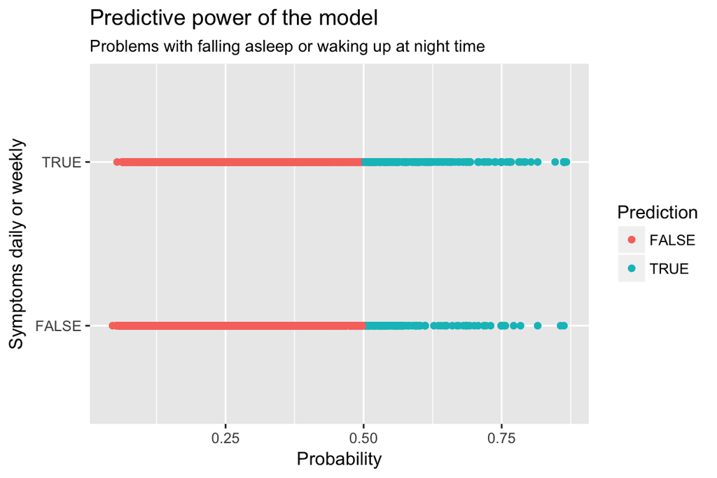

```r
gpp3 <- ggplot(school, aes(x = probability3, y = q13_6often, col = prediction3))
gpp3b <- gpp3 + geom_point() + labs(x = "Probability", y = "Symptoms daily or weekly", title ="Predictive power of the model", subtitle = "Problems with falling asleep or waking up at night time", color = "Prediction")
gpp3b
```

```r
table(q13_6often = school$q13_6often, prediction = school$prediction3) %>% prop.table() %>% addmargins()
```

```
##           prediction
## q13_6often      FALSE       TRUE        Sum
##      FALSE 0.75649642 0.01467294 0.77116935
##      TRUE  0.20318100 0.02564964 0.22883065
##      Sum   0.95967742 0.04032258 1.00000000
```

```r
loss_func3 <- function(class, prob) {
  n_wrong <- abs(class - prob) > 0.5
  mean(n_wrong)
}
loss_func3(class = school$q13_6often, prob = school$probability3)
```

```
## [1] 0.2178539
```

```r
cv3 <- cv.glm(data = school, cost = loss_func3, glmfit = sm3, K = 10)
cv3$delta[1]
```

```
## [1] 0.218638
```

If we look at the matrix above we can see that predictiwe power of this matrix is also quite low if we try to find pupils who have sleep problems daily or weekly. The chance to get true negative is approximately 76% and true positive approximately 3%. The average number of wrong predictions is approximately 0.22.

## Tiredness or weakness

```r
m4 <- glm(q13_8often ~ q1 + q6_7 + q6_8 + q7_9 + q7_10 + q7_11 + q7_12 + q10_1 + q10_2 + q10_3 + q10_4 + q10_5 + q11_1 + q11_2 + q11_3 + q11_15 + q11_16 + q11_17 + q11_18 + q11_19 + q11_20, data = school, family = "binomial")
sm4 <- step(m4, direction="both")
```

```
## Start:  AIC=9779.74
## q13_8often ~ q1 + q6_7 + q6_8 + q7_9 + q7_10 + q7_11 + q7_12 +
##     q10_1 + q10_2 + q10_3 + q10_4 + q10_5 + q11_1 + q11_2 + q11_3 +
##     q11_15 + q11_16 + q11_17 + q11_18 + q11_19 + q11_20
##
##          Df Deviance     AIC
## - q10_5   1   9735.7  9777.7
## - q6_8    1   9735.9  9777.9
## - q11_15  1   9735.9  9777.9
## - q11_18  1   9736.0  9778.0
## - q10_4   1   9736.0  9778.0
## - q11_19  1   9736.8  9778.8
## - q11_16  1   9736.9  9778.9
## - q10_2   1   9737.4  9779.4
## - q11_17  1   9737.4  9779.4
## <none>        9735.7  9779.7
## - q7_11   1   9739.2  9781.2
## - q11_3   1   9739.6  9781.6
## - q6_7    1   9740.8  9782.8
## - q7_12   1   9741.4  9783.4
## - q11_20  1   9743.3  9785.3
## - q7_10   1   9743.5  9785.5
## - q11_1   1   9745.9  9787.9
## - q11_2   1   9746.3  9788.3
## - q7_9    1   9747.4  9789.4
## - q10_1   1   9752.4  9794.4
## - q10_3   1   9755.9  9797.9
## - q1      1  10210.4 10252.4
##
## Step:  AIC=9777.74
## q13_8often ~ q1 + q6_7 + q6_8 + q7_9 + q7_10 + q7_11 + q7_12 +
##     q10_1 + q10_2 + q10_3 + q10_4 + q11_1 + q11_2 + q11_3 + q11_15 +
##     q11_16 + q11_17 + q11_18 + q11_19 + q11_20
##
##          Df Deviance     AIC
## - q6_8    1   9735.9  9775.9
## - q11_15  1   9735.9  9775.9
## - q11_18  1   9736.0  9776.0
## - q10_4   1   9736.1  9776.1
## - q11_19  1   9736.8  9776.8
```

[output cut: 175 more lines]

```
## + q11_18  1   9738.5  9770.5
## + q11_15  1   9738.5  9770.5
## + q10_5   1   9738.5  9770.5
## - q7_11   1   9742.6  9770.6
## - q7_12   1   9744.0  9772.0
## - q6_7    1   9746.4  9774.4
## - q7_10   1   9746.6  9774.6
## - q11_17  1   9747.0  9775.0
## - q11_2   1   9749.0  9777.0
## - q11_20  1   9749.1  9777.1
## - q11_1   1   9749.3  9777.3
## - q7_9    1   9750.6  9778.6
## - q10_1   1   9754.7  9782.7
## - q10_3   1   9763.5  9791.5
## - q1      1  10217.9 10245.9
```

```r
summary.glm(sm4)
```

```
##
## Call:
## glm(formula = q13_8often ~ q1 + q6_7 + q7_9 + q7_10 + q7_11 +
##     q7_12 + q10_1 + q10_2 + q10_3 + q11_1 + q11_2 + q11_3 + q11_17 +
##     q11_20, family = "binomial", data = school)
##
## Deviance Residuals:
##     Min       1Q   Median       3Q      Max
## -2.2279  -0.8348  -0.5897   1.0574   2.3542
##
## Coefficients:
##             Estimate Std. Error z value Pr(>|z|)
## (Intercept)  3.38860    0.16953  19.988  < 2e-16 ***
## q1M         -1.11006    0.05232 -21.218  < 2e-16 ***
## q6_7        -0.08417    0.02990  -2.815 0.004874 **
## q7_9        -0.12461    0.03574  -3.486 0.000490 ***
## q7_10       -0.12122    0.04263  -2.844 0.004456 **
## q7_11       -0.06439    0.03185  -2.022 0.043173 *
## q7_12        0.09501    0.04044   2.349 0.018821 *
## q10_1       -0.17851    0.04425  -4.034 5.48e-05 ***
## q10_2        0.06713    0.04705   1.427 0.153689
## q10_3       -0.17811    0.03546  -5.023 5.07e-07 ***
## q11_1       -0.14688    0.04455  -3.297 0.000978 ***
## q11_2       -0.12028    0.03702  -3.249 0.001159 **
## q11_3        0.06600    0.03712   1.778 0.075369 .
## q11_17      -0.09611    0.03285  -2.926 0.003431 **
## q11_20      -0.10803    0.03305  -3.269 0.001080 **
## ---
## Signif. codes:  0 '***' 0.001 '**' 0.01 '*' 0.05 '.' 0.1 ' ' 1
##
## (Dispersion parameter for binomial family taken to be 1)
##
##     Null deviance: 10930.5  on 8927  degrees of freedom
## Residual deviance:  9738.5  on 8913  degrees of freedom
## AIC: 9768.5
##
## Number of Fisher Scoring iterations: 4
```

The variables which have the greatest and most significant negative connection to tiredness or weakness are

- q1m = Gender: Male
- q7_9 = The teachers treat us with justice.
- q10_1 = My parents appreciate my schoolwork.
- q10_3 = My parents help me with my homework if necessary.
- q11_1 = My work is appreciated at school.

Here are the coefficients of the model:

```r
coef(sm4)
```

```
## (Intercept)         q1M        q6_7        q7_9       q7_10       q7_11
##  3.38860028 -1.11005845 -0.08417490 -0.12461258 -0.12122458 -0.06439419
##       q7_12       q10_1       q10_2       q10_3       q11_1       q11_2
##  0.09500671 -0.17851169  0.06712933 -0.17810994 -0.14688383 -0.12027654
##       q11_3      q11_17      q11_20
##  0.06599888 -0.09611100 -0.10802501
```

### Odds ratios and confidence intervals of the model:

```r
OR4 <- coef(sm4) %>% exp
CI4 <- confint(sm4) %>% exp
cbind(OR4, CI4)
```

```
##                    OR4      2.5 %     97.5 %
## (Intercept) 29.6244574 21.2913582 41.3858932
## q1M          0.3295397  0.2973038  0.3649855
## q6_7         0.9192705  0.8670296  0.9748592
## q7_9         0.8828389  0.8231626  0.9469895
## q7_10        0.8858350  0.8148070  0.9630169
## q7_11        0.9376353  0.8809505  0.9981012
## q7_12        1.0996662  1.0160176  1.1905975
## q10_1        0.8365143  0.7670127  0.9123271
## q10_2        1.0694338  0.9754069  1.1730444
## q10_3        0.8368504  0.7807059  0.8971432
## q11_1        0.8633943  0.7912118  0.9422194
## q11_2        0.8866752  0.8246618  0.9534858
## q11_3        1.0682255  0.9934341  1.1490360
## q11_17       0.9083632  0.8517626  0.9688212
## q11_20       0.8976051  0.8413548  0.9577367
```

If we look at the odds ratios and their confidence intervals here we can see that also here only the gender has big impact on the model (OR = 0.330) meaning that boys have smaller odds to have tiredness or weakness daily or weekly. After gender the biggest impact is on questions q10_3 “My parents help me with my homework if necessary.” (OR = 0.837) and q10_1 “My parents appreciate my schoolwork.” (OR = 0.837).

### The predictive power of this model

```r
probabilities4 <- predict(sm4, type = "response")
school <- mutate(school, probability4 = probabilities4)
school <- mutate(school, prediction4 = probability4 > 0.5)
table(q13_8often = school$q13_8often, prediction = school$prediction4)
```

```
##           prediction
## q13_8often FALSE TRUE
##      FALSE  5792  444
##      TRUE   1939  753
```

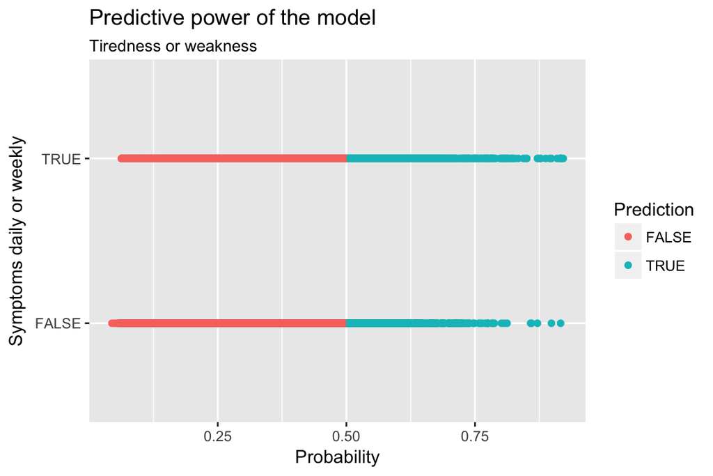

```r
gpp4 <- ggplot(school, aes(x = probability4, y = q13_8often, col = prediction4))
gpp4b <- gpp4 + geom_point() + labs(x = "Probability", y = "Symptoms daily or weekly", title ="Predictive power of the model", subtitle = "Tiredness or weakness", color = "Prediction")
gpp4b
```

```r
table(q13_8often = school$q13_8often, prediction = school$prediction4) %>% prop.table() %>% addmargins()
```

```
##           prediction
## q13_8often      FALSE       TRUE        Sum
##      FALSE 0.64874552 0.04973118 0.69847670
##      TRUE  0.21718190 0.08434140 0.30152330
##      Sum   0.86592742 0.13407258 1.00000000
```

```r
loss_func4 <- function(class, prob) {
  n_wrong <- abs(class - prob) > 0.5
  mean(n_wrong)
}
loss_func4(class = school$q13_8often, prob = school$probability4)
```

```
## [1] 0.2669131
```

```r
cv4 <- cv.glm(data = school, cost = loss_func4, glmfit = sm4, K = 10)
cv4$delta[1]
```

```
## [1] 0.2692652
```

If we look at the matrix above we can see that the predictive power of this model is better than earlier models but it´s still not big enough to find pupils who have tiredness or weakness daily or weekly. There is approximately a 65% chance to get true negative and approximately a 8% chance to get true positive with this model. The average number of wrong predictions is approximately 0.27.

## Depression

```r
m5 <- glm(q13_9often ~ q1 + q6_7 + q6_8 + q7_9 + q7_10 + q7_11 + q7_12 + q10_1 + q10_2 + q10_3 + q10_4 + q10_5 + q11_1 + q11_2 + q11_3 + q11_15 + q11_16 + q11_17 + q11_18 + q11_19 + q11_20, data = school, family = "binomial")
sm5 <- step(m5, direction="both")
```

```
## Start:  AIC=6322.7
## q13_9often ~ q1 + q6_7 + q6_8 + q7_9 + q7_10 + q7_11 + q7_12 +
##     q10_1 + q10_2 + q10_3 + q10_4 + q10_5 + q11_1 + q11_2 + q11_3 +
##     q11_15 + q11_16 + q11_17 + q11_18 + q11_19 + q11_20
##
##          Df Deviance    AIC
## - q11_18  1   6278.9 6320.9
## - q7_11   1   6279.0 6321.0
## - q6_7    1   6279.1 6321.1
## - q11_19  1   6279.1 6321.1
## - q11_17  1   6279.4 6321.4
## - q10_2   1   6279.7 6321.7
## - q7_10   1   6279.8 6321.8
## - q6_8    1   6279.9 6321.9
## <none>        6278.7 6322.7
## - q11_15  1   6281.0 6323.0
## - q7_12   1   6281.3 6323.3
## - q11_3   1   6281.5 6323.5
## - q10_5   1   6283.0 6325.0
## - q11_16  1   6284.9 6326.9
## - q11_1   1   6287.0 6329.0
## - q10_4   1   6287.5 6329.5
## - q11_20  1   6291.9 6333.9
## - q10_3   1   6292.9 6334.9
## - q7_9    1   6293.7 6335.7
## - q10_1   1   6299.3 6341.3
## - q11_2   1   6350.0 6392.0
## - q1      1   6632.3 6674.3
##
## Step:  AIC=6320.94
## q13_9often ~ q1 + q6_7 + q6_8 + q7_9 + q7_10 + q7_11 + q7_12 +
##     q10_1 + q10_2 + q10_3 + q10_4 + q10_5 + q11_1 + q11_2 + q11_3 +
##     q11_15 + q11_16 + q11_17 + q11_19 + q11_20
##
##          Df Deviance    AIC
## - q7_11   1   6279.3 6319.3
## - q6_7    1   6279.3 6319.3
## - q11_19  1   6279.5 6319.5
## - q10_2   1   6279.9 6319.9
## - q7_10   1   6280.0 6320.0
```

[output cut: 231 more lines]

```
## + q11_18  1   6286.1 6314.1
## + q11_19  1   6286.2 6314.2
## + q6_7    1   6286.3 6314.3
## + q7_10   1   6286.4 6314.4
## + q7_11   1   6286.7 6314.7
## - q10_5   1   6291.8 6315.8
## - q10_4   1   6294.6 6318.6
## - q11_1   1   6294.7 6318.7
## - q11_16  1   6297.1 6321.1
## - q10_3   1   6300.5 6324.5
## - q11_20  1   6300.6 6324.6
## - q10_1   1   6307.8 6331.8
## - q7_9    1   6310.8 6334.8
## - q11_2   1   6358.2 6382.2
## - q1      1   6649.5 6673.5
```

```r
summary.glm(sm5)
```

```
##
## Call:
## glm(formula = q13_9often ~ q1 + q6_8 + q7_9 + q10_1 + q10_3 +
##     q10_4 + q10_5 + q11_1 + q11_2 + q11_3 + q11_16 + q11_20,
##     family = "binomial", data = school)
##
## Deviance Residuals:
##     Min       1Q   Median       3Q      Max
## -2.3122  -0.5679  -0.3785  -0.2389   3.0012
##
## Coefficients:
##             Estimate Std. Error z value Pr(>|z|)
## (Intercept)  3.98766    0.20069  19.869  < 2e-16 ***
## q1M         -1.29658    0.07214 -17.974  < 2e-16 ***
## q6_8         0.06336    0.03827   1.656 0.097820 .
## q7_9        -0.18872    0.03830  -4.928 8.31e-07 ***
## q10_1       -0.22628    0.04912  -4.606 4.10e-06 ***
## q10_3       -0.19041    0.05073  -3.753 0.000175 ***
## q10_4       -0.17788    0.06347  -2.803 0.005067 **
## q10_5        0.09482    0.04255   2.229 0.025827 *
## q11_1       -0.15767    0.05582  -2.825 0.004734 **
## q11_2       -0.39730    0.04695  -8.462  < 2e-16 ***
## q11_3        0.08584    0.04762   1.803 0.071458 .
## q11_16      -0.13673    0.04237  -3.227 0.001250 **
## q11_20      -0.15506    0.04155  -3.732 0.000190 ***
## ---
## Signif. codes:  0 '***' 0.001 '**' 0.01 '*' 0.05 '.' 0.1 ' ' 1
##
## (Dispersion parameter for binomial family taken to be 1)
##
##     Null deviance: 7609.4  on 8927  degrees of freedom
## Residual deviance: 6286.8  on 8915  degrees of freedom
## AIC: 6312.8
##
## Number of Fisher Scoring iterations: 5
```

The variables which have the greatest and most significant negative connection to depression are

- q1m = Gender: Male
- q7_9 = The teachers treat us with justice.
- q10_1 = My parents appreciate my schoolwork.
- q10_3 = My parents help me with my homework if necessary.
- q11_2 = At school I´m regarded as a person who has a meaning.
- q11_20 = I reserve acknowledgement if I do well with my tasks.

Here are the coefficients of the model:

```r
coef(sm5)
```

```
## (Intercept)         q1M        q6_8        q7_9       q10_1       q10_3
##  3.98765682 -1.29657649  0.06335752 -0.18872120 -0.22628067 -0.19040563
##       q10_4       q10_5       q11_1       q11_2       q11_3      q11_16
## -0.17787731  0.09482494 -0.15766641 -0.39730263  0.08584266 -0.13672613
##      q11_20
## -0.15506258
```

### Odds ratios and confidence intervals of the model:

```r
OR5 <- coef(sm5) %>% exp
CI5 <- confint(sm5) %>% exp
cbind(OR5, CI5)
```

```
##                    OR5      2.5 %     97.5 %
## (Intercept) 53.9283775 36.4981129 80.1663237
## q1M          0.2734664  0.2371336  0.3146517
## q6_8         1.0654077  0.9886627  1.1487131
## q7_9         0.8280173  0.7682131  0.8926658
## q10_1        0.7974942  0.7243617  0.8782300
## q10_3        0.8266238  0.7487958  0.9136096
## q10_4        0.8370451  0.7390467  0.9478612
## q10_5        1.0994664  1.0121372  1.1958784
## q11_1        0.8541347  0.7656389  0.9529436
## q11_2        0.6721306  0.6130034  0.7369034
## q11_3        1.0896349  0.9928009  1.1965967
## q11_16       0.8722091  0.8028191  0.9478911
## q11_20       0.8563616  0.7895006  0.9291708
```

If we look at the odds ratios and their confidence intervals we can see that gender (OR = 0.273) and question q11_2 “At school I´m regarded as a person who has a meaning.” (OR = 0.672) have really impact on the model meaning that boys and pupils who feel that they have meaning in their schools have smaller odds to have depression. Also questions q10_1 “My parents appreciate my schoolwork.” (OR = 0.797) and q7_9 “The teachers treat us with justice.” (OR = 0.828) have small impact on the model. Other variables are quite near to 1 or even on the both sides of it.

### The predictive power of this model

```r
probabilities5 <- predict(sm5, type = "response")
school <- mutate(school, probability5 = probabilities5)
school <- mutate(school, prediction5 = probability5 > 0.5)
table(q13_9often = school$q13_9often, prediction = school$prediction5)
```

```
##           prediction
## q13_9often FALSE TRUE
##      FALSE  7460  111
##      TRUE   1145  212
```

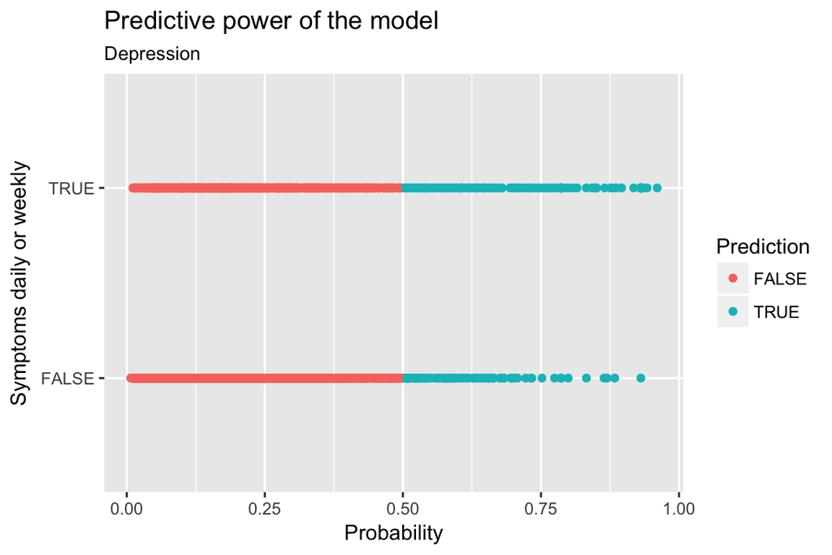

```r
gpp5 <- ggplot(school, aes(x = probability5, y = q13_9often, col = prediction5))
gpp5b <- gpp5 + geom_point() + labs(x = "Probability", y = "Symptoms daily or weekly", title ="Predictive power of the model", subtitle = "Depression", color = "Prediction")
gpp5b
```

```r
table(q13_9often = school$q13_9often, prediction = school$prediction5) %>% prop.table() %>% addmargins()
```

```
##           prediction
## q13_9often      FALSE       TRUE        Sum
##      FALSE 0.83557348 0.01243280 0.84800627
##      TRUE  0.12824821 0.02374552 0.15199373
##      Sum   0.96382168 0.03617832 1.00000000
```

```r
loss_func5 <- function(class, prob) {
  n_wrong <- abs(class - prob) > 0.5
  mean(n_wrong)
}
loss_func5(class = school$q13_9often, prob = school$probability5)
```

```
## [1] 0.140681
```

```r
cv5 <- cv.glm(data = school, cost = loss_func5, glmfit = sm5, K = 10)
cv5$delta[1]
```

```
## [1] 0.141353
```

If we look at the matrix above we can see that the predictive power of also this model is quite low if we try to find pupils who have depression daily or weekly. The chance to get true negative is approximately 84% and true positive approximately 2%. The average number of wrong predictions is approximately 0.14.

## Fear

```r
m6 <- glm(q13_10often ~ q1 + q6_7 + q6_8 + q7_9 + q7_10 + q7_11 + q7_12 + q10_1 + q10_2 + q10_3 + q10_4 + q10_5 + q11_1 + q11_2 + q11_3 + q11_15 + q11_16 + q11_17 + q11_18 + q11_19 + q11_20, data = school, family = "binomial")
sm6 <- step(m6, direction="both")
```

```
## Start:  AIC=3866.23
## q13_10often ~ q1 + q6_7 + q6_8 + q7_9 + q7_10 + q7_11 + q7_12 +
##     q10_1 + q10_2 + q10_3 + q10_4 + q10_5 + q11_1 + q11_2 + q11_3 +
##     q11_15 + q11_16 + q11_17 + q11_18 + q11_19 + q11_20
##
##          Df Deviance    AIC
## - q11_20  1   3822.3 3864.3
## - q11_16  1   3822.3 3864.3
## - q11_19  1   3822.4 3864.4
## - q11_18  1   3822.4 3864.4
## - q10_5   1   3822.7 3864.7
## - q10_2   1   3822.8 3864.8
## - q6_8    1   3822.9 3864.9
## - q7_10   1   3823.2 3865.2
## - q7_12   1   3823.2 3865.2
## <none>        3822.2 3866.2
## - q10_4   1   3824.7 3866.7
## - q6_7    1   3824.8 3866.8
## - q11_3   1   3824.9 3866.9
## - q11_17  1   3825.1 3867.1
## - q7_9    1   3826.0 3868.0
## - q7_11   1   3826.2 3868.2
## - q10_1   1   3827.0 3869.0
## - q10_3   1   3827.4 3869.4
## - q11_15  1   3828.9 3870.9
## - q11_1   1   3830.5 3872.5
## - q11_2   1   3877.1 3919.1
## - q1      1   3937.6 3979.6
##
## Step:  AIC=3864.26
## q13_10often ~ q1 + q6_7 + q6_8 + q7_9 + q7_10 + q7_11 + q7_12 +
##     q10_1 + q10_2 + q10_3 + q10_4 + q10_5 + q11_1 + q11_2 + q11_3 +
##     q11_15 + q11_16 + q11_17 + q11_18 + q11_19
##
##          Df Deviance    AIC
## - q11_16  1   3822.4 3862.4
## - q11_18  1   3822.4 3862.4
## - q11_19  1   3822.5 3862.5
## - q10_5   1   3822.7 3862.7
## - q10_2   1   3822.8 3862.8
```

[output cut: 231 more lines]

```
## + q7_12   1   3825.2 3853.2
## + q10_5   1   3825.2 3853.2
## + q11_19  1   3825.4 3853.4
## + q11_16  1   3825.5 3853.5
## + q11_20  1   3825.5 3853.5
## + q11_18  1   3825.5 3853.5
## - q7_11   1   3830.0 3854.0
## - q10_3   1   3831.2 3855.2
## - q11_17  1   3832.2 3856.2
## - q7_9    1   3832.8 3856.8
## - q10_1   1   3833.2 3857.2
## - q11_15  1   3834.1 3858.1
## - q11_1   1   3834.7 3858.7
## - q11_2   1   3881.3 3905.3
## - q1      1   3945.1 3969.1
```

```r
summary.glm(sm6)
```

```
##
## Call:
## glm(formula = q13_10often ~ q1 + q6_7 + q7_9 + q7_11 + q10_1 +
##     q10_3 + q10_4 + q11_1 + q11_2 + q11_3 + q11_15 + q11_17,
##     family = "binomial", data = school)
##
## Deviance Residuals:
##     Min       1Q   Median       3Q      Max
## -1.8760  -0.3848  -0.2699  -0.1862   3.2100
##
## Coefficients:
##             Estimate Std. Error z value Pr(>|z|)
## (Intercept)  2.94992    0.22528  13.094  < 2e-16 ***
## q1M         -1.02163    0.09766 -10.461  < 2e-16 ***
## q6_7         0.07766    0.05189   1.496  0.13453
## q7_9        -0.14721    0.05461  -2.695  0.00703 **
## q7_11        0.11223    0.05353   2.097  0.03601 *
## q10_1       -0.17569    0.06345  -2.769  0.00562 **
## q10_3       -0.16099    0.06680  -2.410  0.01596 *
## q10_4       -0.13344    0.07858  -1.698  0.08947 .
## q11_1       -0.22368    0.07410  -3.019  0.00254 **
## q11_2       -0.47135    0.06322  -7.456  8.9e-14 ***
## q11_3        0.10178    0.06524   1.560  0.11874
## q11_15      -0.20113    0.06872  -2.927  0.00342 **
## q11_17      -0.15717    0.06075  -2.587  0.00967 **
## ---
## Signif. codes:  0 '***' 0.001 '**' 0.01 '*' 0.05 '.' 0.1 ' ' 1
##
## (Dispersion parameter for binomial family taken to be 1)
##
##     Null deviance: 4596.1  on 8927  degrees of freedom
## Residual deviance: 3825.6  on 8915  degrees of freedom
## AIC: 3851.6
##
## Number of Fisher Scoring iterations: 6
```

The variables which have the greatest and most significant negative connection to fear are

- q1m = Gender: Male
- q11_2 = At school I´m regarded as a person who has a meaning.

Here are the coefficients of the model:

```r
coef(sm6)
```

```
## (Intercept)         q1M        q6_7        q7_9       q7_11       q10_1
##  2.94992248 -1.02162798  0.07765685 -0.14721213  0.11223448 -0.17569006
##       q10_3       q10_4       q11_1       q11_2       q11_3      q11_15
## -0.16098940 -0.13344171 -0.22367839 -0.47135112  0.10178359 -0.20113071
##      q11_17
## -0.15717107
```

### Odds ratios and confidence intervals of the model:

```r
OR6 <- coef(sm6) %>% exp
CI6 <- confint(sm6) %>% exp
cbind(OR6, CI6)
```

```
##                    OR6      2.5 %     97.5 %
## (Intercept) 19.1044726 12.3211623 29.8076146
## q1M          0.3600084  0.2966675  0.4351210
## q6_7         1.0807517  0.9767041  1.1970859
## q7_9         0.8631109  0.7757697  0.9610096
## q7_11        1.1187752  1.0075183  1.2427787
## q10_1        0.8388779  0.7410942  0.9504057
## q10_3        0.8513011  0.7480447  0.9720521
## q10_4        0.8750785  0.7499343  1.0205497
## q11_1        0.7995722  0.6914900  0.9245907
## q11_2        0.6241584  0.5513716  0.7064366
## q11_3        1.1071438  0.9745824  1.2586410
## q11_15       0.8178055  0.7147049  0.9356930
## q11_17       0.8545579  0.7590779  0.9631971
```

If we look at the odds ratios and their confidence intervals also here we can see that gender has the biggest impact on the model (OR = 0.360) meaning that boys have smaller odds to feel fear daily or weekly. Also question q11_2 “At school I´m regarded as a person who has a meaning.” has quite small odds ratio (OR = 0.624) meaning the bigger the score the smaller the odds to feel fear daily or weekly. Question q11_1 “My work is appreciated at school.” (OR = 0.800) might have some impact on the model but it´s confidence interval is quite wide.

### The predictive power of this model

```r
probabilities6 <- predict(sm6, type = "response")
school <- mutate(school, probability6 = probabilities6)
school <- mutate(school, prediction6 = probability6 > 0.5)
table(q13_10often = school$q13_10often, prediction = school$prediction6)
```

```
##            prediction
## q13_10often FALSE TRUE
##       FALSE  8268   22
##       TRUE    566   72
```

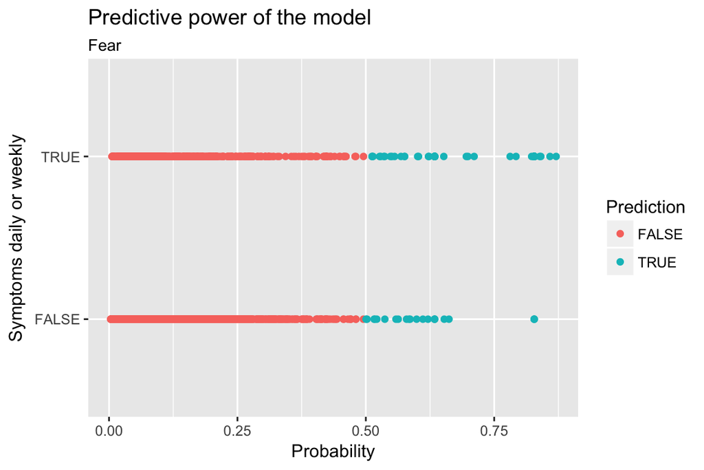

```r
gpp6 <- ggplot(school, aes(x = probability6, y = q13_10often, col = prediction6))
gpp6b <- gpp6 + geom_point() + labs(x = "Probability", y = "Symptoms daily or weekly", title ="Predictive power of the model", subtitle = "Fear", color = "Prediction")
gpp6b
```

```r
table(q13_10often = school$q13_10often, prediction = school$prediction6) %>% prop.table() %>% addmargins()
```

```
##            prediction
## q13_10often       FALSE        TRUE         Sum
##       FALSE 0.926075269 0.002464158 0.928539427
##       TRUE  0.063396057 0.008064516 0.071460573
##       Sum   0.989471326 0.010528674 1.000000000
```

```r
loss_func6 <- function(class, prob) {
  n_wrong <- abs(class - prob) > 0.5
  mean(n_wrong)
}
loss_func6(class = school$q13_10often, prob = school$probability6)
```

```
## [1] 0.06586022
```

```r
cv6 <- cv.glm(data = school, cost = loss_func6, glmfit = sm6, K = 10)
cv6$delta[1]
```

```
## [1] 0.06630824
```

If we look at the plot above we can see that the predictive power of this model is the smallest of all these models if we try to predict pupils who have fear daily or weekly. The chance to get true negative is approximately 93% and true positive approximately only 1%. The average number of wrong predictions is approximately 0.07.

# Conclusions and discussion

As we have seen earlier it is quite hard to predict mental symptoms which occur daily or weekly with questions about relationships with teachers and parents and the support they will provide. There are some variables which have more connection to these symptoms than others. The most important one is gender. It seems that overall boys have less or more rarely mental symptoms daily or weekly than girls.

For tension and nervousness Likert-scale questions q11_2 = “At school I´m regarded as a person who has a meaning.” and q10_3 “My parents help me with my homework if necessary.” were the most important. For irritability or outbursts of anger the same questions as for tension and nervousness and also the question q7_10 “It is easy to get along with the teachers.” were the most important. For sleep problems and also for tiredness and weakness the most important questions were q10_1 “My parents appreciate my schoolwork.” and q10_3 “My parents help me with my homework if necessary.” With depression the question q11_2 “At school I´m regarded as a person who has a meaning.” had the greatest connection and also questions q10_1 “My parents appreciate my schoolwork.”and q7_9 “The teachers treat us with justice.” had small impact on the model. Feeling fear was most connected to question q11_2 “At school I´m regarded as a person who has a meaning.” and also to question q11_1 “My work is appreciated at school.” So the parents quite practical support, the feeling of having meaning in school and feeling oneself appreciated seem to be the most meaningfulfactors in respect of better mental health. It´s good to note that the relationship is two-way. For example in depression feeling having no meaning can be a symptom itself and work as a vicious circle.

All in all if we look at these results we can see that only few of the questions have some relationship with the symptoms but these relationships aren´t very big (except gender). By themselves they cannot form a model which could predict mental symptoms which occur daily or weekly well enough.

There are also some weaknesses in my analysis. I changed all the scales except gender to numeric. I could have used ordinal regression which seems to be the recommended option for Likert-scale questions. I also could have paid more attention to the missing values and see if there is some clear pattern between them. And if necessary I could have used imputation to fill those gaps. Hopefully for the next analysis I have more skills to make it in a better way.

If we think the original purpose of this data and the project behind it we can notice that it´s purpose is to find out how the pupils see their school, their teachers and support they get and if they have some symptoms or illnesses which can influence the school days. So although the models created here weren´t so suitable the project itself provides a good tool to evaluate the quality of school and notice if there is something which needs improvement or special attention. Even though most of the pupils feel well in the school and home there are also those who feel the opposite and these adolescents need special attention and help to get as good as possible tools and support for life.

# References

Konu, Anne (University of Tampere): School´s Well Being Profile 2015-2016: Lower secondary school, grades 7-9 [electronic archive]. Version 1.0 (2016-07-18). The Finnish Social Science Data Archive [distributor]. http://urn.fi/urn:nbn:fi:fsd:T-FSD3117